# Лабораторная работа 1. Иерархический анализ

Natalia Korskova

2016-03-23

### Растения Армориканской возвышенности

#### Чтение и изучение данных

Считываем данные из файла:

```r
plants.01 <- read.table("plants.dat", header = TRUE, sep = ";")
```

Посмотрим на структуру данных и summary:

```r
str(plants.01)
```

```
## 'data.frame':    136 obs. of  32 variables:
##  $ plant.name: Factor w/ 136 levels "Aceca","Aceps",..: 1 2 3 4 5 6 7 8 9 10 ...
##  $ pdias     : num  96.84 110.72 0.06 0.08 1.48 ...
##  $ longindex : num  0 0 0.667 0.489 0.476 ...
##  $ durflow   : int  2 3 3 2 3 3 3 3 3 3 ...
##  $ height    : int  7 8 2 2 2 5 2 2 3 2 ...
##  $ begflow   : int  5 4 6 7 5 4 6 3 7 4 ...
##  $ mycor     : int  2 2 2 1 2 0 2 2 2 2 ...
##  $ vegaer    : int  0 0 0 2 2 0 0 0 0 0 ...
##  $ vegsout   : int  0 0 1 0 0 0 0 2 0 0 ...
##  $ autopoll  : int  0 0 0 0 1 3 3 1 0 2 ...
##  $ insects   : int  4 4 0 0 3 3 2 3 3 0 ...
##  $ wind      : int  0 0 4 4 0 0 0 0 0 3 ...
##  $ lign      : int  1 1 0 0 0 0 0 0 0 0 ...
##  $ piq       : int  0 0 0 0 0 0 0 0 0 0 ...
```

[output cut: 18 more lines]

```r
summary(plants.01)
```

```
##    plant.name      pdias            longindex         durflow
##  Aceca  :  1   Min.   :   0.010   Min.   :0.0000   Min.   : 1.000
##  Aceps  :  1   1st Qu.:   0.460   1st Qu.:0.0000   1st Qu.: 2.000
##  Agrca  :  1   Median :   1.575   Median :0.4444   Median : 3.000
##  Agrst  :  1   Mean   :  70.764   Mean   :0.4060   Mean   : 3.184
##  Ajure  :  1   3rd Qu.:   8.505   3rd Qu.:0.7230   3rd Qu.: 4.000
##  Allpe  :  1   Max.   :1684.300   Max.   :1.0000   Max.   :12.000
##  (Other):130   NA's   :36         NA's   :25
##      height         begflow          mycor           vegaer
##  Min.   :1.000   Min.   :1.000   Min.   :0.000   Min.   :0.0000
##  1st Qu.:2.000   1st Qu.:4.000   1st Qu.:1.000   1st Qu.:0.0000
##  Median :4.000   Median :5.000   Median :2.000   Median :0.0000
##  Mean   :4.118   Mean   :5.169   Mean   :1.598   Mean   :0.2164
##  3rd Qu.:5.000   3rd Qu.:6.000   3rd Qu.:2.000   3rd Qu.:0.0000
##  Max.   :8.000   Max.   :9.000   Max.   :2.000   Max.   :2.0000
##                                  NA's   :39      NA's   :2
##     vegsout          autopoll         insects           wind
##  Min.   :0.0000   Min.   :0.0000   Min.   :0.000   Min.   :0.0000
##  1st Qu.:0.0000   1st Qu.:0.0000   1st Qu.:0.000   1st Qu.:0.0000
##  Median :0.0000   Median :0.0000   Median :3.000   Median :0.0000
##  Mean   :0.4254   Mean   :0.8897   Mean   :2.022   Mean   :0.9853
##  3rd Qu.:1.0000   3rd Qu.:2.0000   3rd Qu.:3.000   3rd Qu.:3.0000
##  Max.   :2.0000   Max.   :3.0000   Max.   :4.000   Max.   :4.0000
##  NA's   :2
##       lign             piq             ros             semiros
##  Min.   :0.0000   Min.   :0.000   Min.   :0.00000   Min.   :0.0000
##  1st Qu.:0.0000   1st Qu.:0.000   1st Qu.:0.00000   1st Qu.:0.0000
##  Median :0.0000   Median :0.000   Median :0.00000   Median :0.0000
##  Mean   :0.3162   Mean   :0.125   Mean   :0.09091   Mean   :0.2652
##  3rd Qu.:1.0000   3rd Qu.:0.000   3rd Qu.:0.00000   3rd Qu.:1.0000
##  Max.   :1.0000   Max.   :1.000   Max.   :1.00000   Max.   :1.0000
##                                   NA's   :4         NA's   :4
##      leafy            suman            winan            monocarp
##  Min.   :0.0000   Min.   :0.0000   Min.   :0.00000   Min.   :0.00000
##  1st Qu.:0.0000   1st Qu.:0.0000   1st Qu.:0.00000   1st Qu.:0.00000
##  Median :1.0000   Median :0.0000   Median :0.00000   Median :0.00000
##  Mean   :0.6439   Mean   :0.1397   Mean   :0.08824   Mean   :0.06618
##  3rd Qu.:1.0000   3rd Qu.:0.0000   3rd Qu.:0.00000   3rd Qu.:0.00000
##  Max.   :1.0000   Max.   :1.0000   Max.   :1.00000   Max.   :1.00000
##  NA's   :4
```

[output cut: 9 more lines]

```
##  Min.   :0.0000   Min.   :0.0000   Min.   :0.0000   Min.   :0.0000
##  1st Qu.:0.0000   1st Qu.:0.0000   1st Qu.:0.0000   1st Qu.:0.0000
##  Median :0.0000   Median :0.0000   Median :0.0000   Median :0.0000
##  Mean   :0.4091   Mean   :0.1515   Mean   :0.0916   Mean   :0.2901
##  3rd Qu.:1.0000   3rd Qu.:0.0000   3rd Qu.:0.0000   3rd Qu.:1.0000
##  Max.   :1.0000   Max.   :1.0000   Max.   :1.0000   Max.   :1.0000
##  NA's   :4        NA's   :4        NA's   :5        NA's   :5
##      epizoo           aquat            windgl            unsp
##  Min.   :0.0000   Min.   :0.0000   Min.   :0.0000   Min.   :0.0000
##  1st Qu.:0.0000   1st Qu.:0.0000   1st Qu.:0.0000   1st Qu.:0.0000
##  Median :0.0000   Median :0.0000   Median :0.0000   Median :0.0000
##  Mean   :0.1679   Mean   :0.0229   Mean   :0.1756   Mean   :0.2901
##  3rd Qu.:0.0000   3rd Qu.:0.0000   3rd Qu.:0.0000   3rd Qu.:1.0000
##  Max.   :1.0000   Max.   :1.0000   Max.   :1.0000   Max.   :1.0000
##  NA's   :5        NA's   :5        NA's   :5        NA's   :5
```

В выборке наблюдаются различные растения, каждый с уникальным plant.name, для которых изучается влияние человеческой деятельности на растения. Величина pdias отвечает за массу диаспоры – части растения различной морфологической природы (спора, семя, плод, клубень и т. п.), естественно отделяющаяся от материнского организма и служащая для размножения и расселения. Для этой величины 36 пропущенных значений. Величина longindex отвечает за срок всхожести семян, здесь 25 пропущенных значений. Остальные значения хоть и распознаны как int, на самом деле являются факторами – либо бинарными и принимают значения 0 или 1, либо имеют несколько уровней: от 1 до 8, от 1 до 9, от 0 до 4 и т.д. Отдельно обратим внимание на mycor – наличие микоризы (симбиотическая ассоциация мицелия гриба с корнями высших растений). Этот фактор принимает значение 0, если микоризы никогда не бывает, 1 – если бывает иногда, 2 – если всегда. Для этой величины 39 пропущенных значений – почти треть всех наблюдений. Посмотрим на описательные статистики выборки, задав нужные типы данных при чтении:

```r
plants.factor <- read.table("plants.dat", header = TRUE, sep = ";", colClasses = c("character", "numeric", "numeric", rep("factor", 29)))
summary(plants.factor)
```

```
##   plant.name            pdias            longindex         durflow
##  Length:136         Min.   :   0.010   Min.   :0.0000   3      :47
##  Class :character   1st Qu.:   0.460   1st Qu.:0.0000   2      :46
##  Mode  :character   Median :   1.575   Median :0.4444   4      :23
##                     Mean   :  70.764   Mean   :0.4060   5      : 8
##                     3rd Qu.:   8.505   3rd Qu.:0.7230   1      : 4
##                     Max.   :1684.300   Max.   :1.0000   6      : 3
##                     NA's   :36         NA's   :25       (Other): 5
##      height      begflow    mycor     vegaer    vegsout   autopoll insects
##  2      :32   5      :42   0   :10   0   :117   0   :96   0:73     0:41
##  3      :26   6      :39   1   :19   1   :  5   1   :19   1:26     1:11
##  5      :22   4      :19   2   :68   2   : 12   2   :19   2:16     2: 5
##  4      :21   7      :15   NA's:39   NA's:  2   NA's: 2   3:21     3:62
##  8      :16   3      :12                                           4:17
##  6      : 7   2      : 3
##  (Other):12   (Other): 6
##  wind   lign   piq       ros      semiros    leafy    suman   winan
##  0:95   0:93   0:119   0   :120   0   :97   0   :47   0:117   0:124
##  1: 2   1:43   1: 17   1   : 12   1   :35   1   :85   1: 19   1: 12
##  2: 2                  NA's:  4   NA's: 4   NA's: 4
##  3:20
##  4:17
##
##
##  monocarp polycarp seasaes   seashiv    seasver    everalw   everparti
##  0:127    0: 19    0   :85   0   :128   0   :126   0   :78   0   :112
##  1:  9    1:117    1   :47   1   :  4   1   :  6   1   :54   1   : 20
##                    NA's: 4   NA's:  4   NA's:  4   NA's: 4   NA's:  4
##
##
##
##
##   elaio     endozoo    epizoo     aquat      windgl      unsp
##  0   :119   0   :93   0   :109   0   :128   0   :108   0   :93
##  1   : 12   1   :38   1   : 22   1   :  3   1   : 23   1   :38
##  NA's:  5   NA's: 5   NA's:  5   NA's:  5   NA's:  5   NA's: 5
##
##
##
##
```

Для фактора, отвечающему за наличие микоризы, только в 10 случаях из примерно 100 (которые не NA) микоризы нет. Это похоже на данные по генеральной совокупности всех растений: симбионт с грибами есть у всех голосеменных растений, у примерно 70% однодольных и 80—90% двудольных. Поэтому отбросим этот фактор как имеющий большое количество пропущенных значений. По причине большой пропущенности значений придётся отбросить и величины pdias и longindex. Величины, для которых количество пропущенных значений 5 и менее, остаются в выборке.

```r
plants.02 <- subset(plants.01, select = -c(2, 3, 7))
```

#### Нормализация данных

В оставшей выборке помимо названий растений остальные величины являются факторами, поэтому было бы неплохо рассмотреть разные способы нормализации. Сделаем две выборки – с feature-scaling с максимумом 1 и минимумом 0 и вторую со средним 0 и отклонением 1:

```r
normalize <- function(x) {
    return ((x - min(na.omit(x))) / (max(na.omit(x)) - min(na.omit(x))))
  }

plants.02.fs <- as.data.frame(lapply(plants.02[, 2:29], normalize))

plants.02.n  <- scale(plants.02[,2:29], center = TRUE, scale = TRUE)
```

#### Кластеризация:

Составляем матрицу попарных расстояний, проводим кластерный анализ:

```r
clust.fs <- hclust(dist(plants.02.fs), "ward.D")
clust.n <- hclust(dist(plants.02.n), "ward.D")
```

Дендрограмма для нормализации feature-scaling:

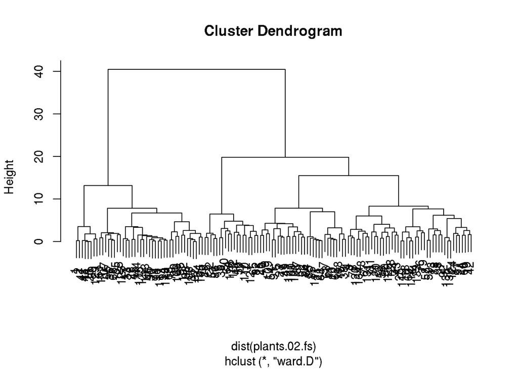

```r
plot(clust.fs)
```

Визуально хочется разбить на 5 кластеров следующим образом:

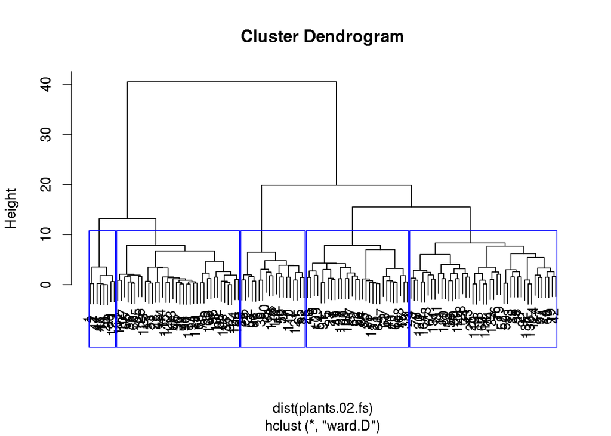

```r
plot(clust.fs)
rect.hclust(clust.fs, k=5, border="blue")
```

Такое количество кластеров следует проверить другими методами. Для начала посмотрим, какой результат даст работа пакета NbClust. Оставлены только те индексы, которые работают за приемлемое время (не давая ошибки о необратимости матрицы) и в качестве ответа дают не максимально возможно число кластеров:

```r
library(NbClust)

NbClust(data = plants.02.fs, method = "ward.D", min.nc = 2, max.nc = 50, index = "kl")
```

```
## $All.index
##      2      3      4      5      6      7      8      9     10     11
## 1.2527 1.1639 2.0188 0.7863 1.9239 0.7509 1.3728 0.9377 1.0226 0.9284
##     12     13     14     15     16     17     18     19     20     21
## 2.1219 0.6409 1.3190 1.0115 1.1453 0.7376 1.1464 1.0132 0.9556 1.1203
##     22     23     24     25     26     27     28     29     30     31
## 1.2620 0.9483 1.5308 0.8587 1.2065 0.7139 1.2002 0.9786 0.8605 0.9397
##     32     33     34     35     36     37     38     39     40     41
## 1.0885 1.4843 0.7585 1.0912 0.8860 1.0020 1.2386 1.0242 1.5240 0.6458
##     42     43     44     45     46     47     48     49     50
## 0.9982 1.2322 0.8463 1.1558 1.1272 0.8412 1.0564 1.0881 1.1597
##
## $Best.nc
## Number_clusters     Value_Index
##         12.0000          2.1219
##
## $Best.partition
##   [1]  1  1  2  2  3  4  4  5  3  6  6  2  5  7  3  4  8  1  1  7  9 10  3
##  [24]  1 10  3  5  8  8  8  8  8  2  9 11  3  3  3  6  1  2  8  8  8  7  7
##  [47] 12  4 10  3  3  3 11  2  6  5  5  1 11  4  4 11  2 11 11  3  8  2 10
##  [70] 10  2  2  9  4  6  4  9  9  9 10 12  5  7  2  3 12  8 11  8 12  8  3
##  [93]  3  2  8  8 11 11  3  3  9  9 11  8  1  8  4  8  8 10  2  4  8 12 11
## [116]  2 12  2  7  6  2  4 10 12 12
```

```r
NbClust(data = plants.02.fs, method = "ward.D", min.nc = 2, max.nc = 50, index = "hartigan")
```

```
## $All.index
##       2       3       4       5       6       7       8       9      10
## 16.7924 14.7622  8.2303 10.0281  5.8300  7.3943  5.6873  6.0601  6.0354
##      11      12      13      14      15      16      17      18      19
##  6.6003  3.4660  5.1259  4.0590  4.0571  3.6312  4.8558  4.3680  4.4000
##      20      21      22      23      24      25      26      27      28
##  4.6940  4.3169  3.5400  3.7784  2.5886  2.9965  2.5467  3.5201  3.0128
##      29      30      31      32      33      34      35      36      37
##  3.1172  3.6592  3.9762  3.7548  2.6246  3.4691  3.2556  3.7427  3.8354
##      38      39      40      41      42      43      44      45      46
##  3.1907  3.1818  2.1588  3.3351  3.4223  2.8538  3.4328  3.0507  2.7696
##      47      48      49      50
##  3.3542  3.2616  3.0765  2.7185
##
## $Best.nc
## Number_clusters     Value_Index
##          4.0000          6.5319
##
## $Best.partition
##   [1] 1 1 1 1 2 3 3 2 2 1 1 1 2 1 2 3 4 1 1 1 2 1 2 1 1 2 2 4 4 4 4 4 1 2 4
##  [36] 2 2 2 1 1 1 4 4 4 1 1 2 3 1 2 2 2 4 1 1 2 2 1 4 3 3 4 1 4 4 2 4 1 1 1
##  [71] 1 1 2 3 1 3 2 2 2 1 2 2 1 1 2 2 4 4 4 2 4 2 2 1 4 4 4 4 2 2 2 2 4 4 1
## [106] 4 3 4 4 1 1 3 4 2 4 1 2 1 1 1 1 3 1 2 2
```

```r
NbClust(data = plants.02.fs, method = "ward.D", min.nc = 2, max.nc = 50, index = "duda")
```

```
## $All.index
##      2      3      4      5      6      7      8      9     10     11
## 0.8648 0.8072 0.8451 0.7946 0.7155 0.8587 0.7844 0.4667 0.6890 0.8064
##     12     13     14     15     16     17     18     19     20     21
## 0.6751 0.7646 0.8199 0.5172 0.5983 0.7624 0.4786 0.7538 0.6001 0.7091
##     22     23     24     25     26     27     28     29     30     31
## 1.0359 0.6090 0.6560 0.7060 0.4779 0.5445 0.4496 0.7139 0.5430 0.6030
##     32     33     34     35     36     37     38     39     40     41
## 0.4400 0.1926 0.4442 0.6274 0.9580 1.3278 0.2831 0.5217 0.3335 1.6800
##     42     43     44     45     46     47     48     49     50
## 1.3833 0.3345 1.5143 1.8804 0.7554 5.2068 4.9185 1.7514 0.4539
##
## $All.CriticalValues
##      2      3      4      5      6      7      8      9     10     11
## 0.8903 0.8636 0.8502 0.8423 0.8259 0.8405 0.8087 0.7666 0.7520 0.7976
##     12     13     14     15     16     17     18     19     20     21
## 0.7888 0.7666 0.7729 0.6793 0.7232 0.7232 0.6793 0.7340 0.6587 0.6963
##     22     23     24     25     26     27     28     29     30     31
## 0.6004 0.6793 0.7520 0.6793 0.7232 0.6332 0.6004 0.6332 0.6332 0.6004
##     32     33     34     35     36     37     38     39     40     41
## 0.5559 0.5559 0.5559 0.6587 0.5559 0.4907 0.5559 0.6004 0.6793 0.4907
##     42     43     44     45     46     47     48     49     50
## 0.4907 0.5559 0.4907 0.5559 0.6793 0.3813 0.3813 0.5559 0.5559
##
## $Best.nc
## Number_clusters     Value_Index
##          7.0000          0.8587
##
## $Best.partition
##   [1] 1 1 1 1 2 3 3 4 2 1 1 1 4 5 2 3 6 1 1 5 2 1 2 1 1 2 4 6 6 6 6 6 1 2 7
##  [36] 2 2 2 1 1 1 6 6 6 5 5 4 3 1 2 2 2 7 1 1 4 4 1 7 3 3 7 1 7 7 2 6 1 1 1
##  [71] 1 1 2 3 1 3 2 2 2 1 4 4 5 1 2 4 6 7 6 4 6 2 2 1 6 6 7 7 2 2 2 2 7 6 1
## [106] 6 3 6 6 1 1 3 6 4 7 1 4 1 5 1 1 3 1 4 4
```

```r
NbClust(data = plants.02.fs, method = "ward.D", min.nc = 2, max.nc = 50, index = "pseudot2")
```

```
## $All.index
##       2       3       4       5       6       7       8       9      10
## 14.3800 12.6582  7.6972  9.5664 11.5295  5.9252  6.3235 15.9991  5.4154
##      11      12      13      14      15      16      17      18      19
##  4.8012  8.6630  4.3103  3.2949  5.6014  6.0422  2.8054  6.5363  3.2668
##      20      21      22      23      24      25      26      27      28
##  3.3319  2.8715 -0.1041  3.8530  6.2918  2.4988  9.8334  3.3460  3.6726
##      29      30      31      32      33      34      35      36      37
##  1.6029  3.3667  1.9748  2.5458  8.3829  2.5025  2.9698  0.0876 -0.2469
##      38      39      40      41      42      43      44      45      46
##  5.0638  2.7501 11.9892 -0.4047 -0.2771  3.9796 -0.3396 -0.9364  1.9423
##      47      48      49      50
##  0.0000  0.0000 -0.8581  2.4060
##
## $All.CriticalValues
##       2       3       4       5       6       7       8       9      10
## 11.3314  8.3692  7.3995  6.9267  6.1133  6.8292  5.4403  4.2631  3.9569
##      11      12      13      14      15      16      17      18      19
##  5.0757  4.8190  4.2631  4.4084  2.8326  3.4454  3.4454  2.8326  3.6244
##      20      21      22      23      24      25      26      27      28
##  2.5904  3.0525  1.9969  2.8326  3.9569  2.8326  3.4454  2.3171  1.9969
##      29      30      31      32      33      34      35      36      37
##  2.3171  2.3171  1.9969  1.5979  1.5979  1.5979  2.5904  1.5979  1.0379
##      38      39      40      41      42      43      44      45      46
##  1.5979  1.9969  2.8326  1.0379  1.0379  1.5979  1.0379  1.5979  2.8326
##      47      48      49      50
##  0.0000  0.0000  1.5979  1.5979
##
## $Best.nc
## Number_clusters     Value_Index
##          7.0000          5.9252
##
## $Best.partition
##   [1] 1 1 1 1 2 3 3 4 2 1 1 1 4 5 2 3 6 1 1 5 2 1 2 1 1 2 4 6 6 6 6 6 1 2 7
##  [36] 2 2 2 1 1 1 6 6 6 5 5 4 3 1 2 2 2 7 1 1 4 4 1 7 3 3 7 1 7 7 2 6 1 1 1
##  [71] 1 1 2 3 1 3 2 2 2 1 4 4 5 1 2 4 6 7 6 4 6 2 2 1 6 6 7 7 2 2 2 2 7 6 1
## [106] 6 3 6 6 1 1 3 6 4 7 1 4 1 5 1 1 3 1 4 4
```

```r
NbClust(data = plants.02.fs, method = "ward.D", min.nc = 2, max.nc = 50, index = "ratkowsky")
```

```
## $All.index
##      2      3      4      5      6      7      8      9     10     11
## 0.1852 0.2172 0.2372 0.2310 0.2312 0.2189 0.2124 0.2081 0.2020 0.2001
##     12     13     14     15     16     17     18     19     20     21
## 0.1966 0.1927 0.1888 0.1875 0.1840 0.1802 0.1805 0.1782 0.1770 0.1744
##     22     23     24     25     26     27     28     29     30     31
## 0.1723 0.1704 0.1683 0.1655 0.1632 0.1610 0.1590 0.1571 0.1553 0.1534
##     32     33     34     35     36     37     38     39     40     41
## 0.1519 0.1515 0.1497 0.1480 0.1466 0.1455 0.1443 0.1427 0.1419 0.1405
##     42     43     44     45     46     47     48     49     50
## 0.1393 0.1380 0.1369 0.1357 0.1348 0.1339 0.1328 0.1318 0.1308
##
## $Best.nc
## Number_clusters     Value_Index
##          4.0000          0.2372
##
## $Best.partition
##   [1] 1 1 1 1 2 3 3 2 2 1 1 1 2 1 2 3 4 1 1 1 2 1 2 1 1 2 2 4 4 4 4 4 1 2 4
##  [36] 2 2 2 1 1 1 4 4 4 1 1 2 3 1 2 2 2 4 1 1 2 2 1 4 3 3 4 1 4 4 2 4 1 1 1
##  [71] 1 1 2 3 1 3 2 2 2 1 2 2 1 1 2 2 4 4 4 2 4 2 2 1 4 4 4 4 2 2 2 2 4 4 1
## [106] 4 3 4 4 1 1 3 4 2 4 1 2 1 1 1 1 3 1 2 2
```

```r
NbClust(data = plants.02.fs, method = "ward.D", min.nc = 2, max.nc = 50, index = "ball")
```

```
## $All.index
##        2        3        4        5        6        7        8        9
## 184.6054 108.2866  72.4485  54.2676  41.7353  34.1024  28.0800  23.8030
##       10       11       12       13       14       15       16       17
##  20.3590  17.5853  15.2377  13.6469  12.1176  10.9108   9.8650   8.9854
##       18       19       20       21       22       23       24       25
##   8.1210   7.3919   6.7424   6.1466   5.6333   5.2094   4.8140   4.5059
##       26       27       28       29       30       31       32       33
##   4.2066   3.9492   3.6761   3.4424   3.2230   3.0034   2.7914   2.6018
##       34       35       36       37       38       39       40       41
##   2.4552   2.2975   2.1557   2.0128   1.8780   1.7651   1.6596   1.5790
##       42       43       44       45       46       47       48       49
##   1.4825   1.3907   1.3134   1.2320   1.1609   1.0978   1.0306   0.9685
##       50
##   0.9122
##
## $Best.nc
## Number_clusters     Value_Index
##          3.0000         76.3189
##
## $Best.partition
##   [1] 1 1 1 1 2 1 1 2 2 1 1 1 2 1 2 1 3 1 1 1 2 1 2 1 1 2 2 3 3 3 3 3 1 2 3
##  [36] 2 2 2 1 1 1 3 3 3 1 1 2 1 1 2 2 2 3 1 1 2 2 1 3 1 1 3 1 3 3 2 3 1 1 1
##  [71] 1 1 2 1 1 1 2 2 2 1 2 2 1 1 2 2 3 3 3 2 3 2 2 1 3 3 3 3 2 2 2 2 3 3 1
## [106] 3 1 3 3 1 1 1 3 2 3 1 2 1 1 1 1 1 1 2 2
```

```r
NbClust(data = plants.02.fs, method = "ward.D", min.nc = 2, max.nc = 50, index = "ptbiserial")
```

```
## $All.index
##      2      3      4      5      6      7      8      9     10     11
## 0.1887 0.3959 0.5244 0.5308 0.5596 0.4969 0.5182 0.4982 0.5014 0.5097
##     12     13     14     15     16     17     18     19     20     21
## 0.5228 0.4750 0.4769 0.4743 0.4737 0.4680 0.4790 0.4811 0.4866 0.4913
##     22     23     24     25     26     27     28     29     30     31
## 0.4955 0.4953 0.4943 0.4679 0.4658 0.4532 0.4532 0.4515 0.4511 0.4520
##     32     33     34     35     36     37     38     39     40     41
## 0.4552 0.4567 0.4552 0.4562 0.4526 0.4545 0.4558 0.4555 0.4544 0.4483
##     42     43     44     45     46     47     48     49     50
## 0.4489 0.4496 0.4481 0.4488 0.4487 0.4412 0.4417 0.4421 0.4417
##
## $Best.nc
## Number_clusters     Value_Index
##          6.0000          0.5596
##
## $Best.partition
##   [1] 1 1 1 1 2 3 3 4 2 1 1 1 4 5 2 3 6 1 1 5 2 1 2 1 1 2 4 6 6 6 6 6 1 2 6
##  [36] 2 2 2 1 1 1 6 6 6 5 5 4 3 1 2 2 2 6 1 1 4 4 1 6 3 3 6 1 6 6 2 6 1 1 1
##  [71] 1 1 2 3 1 3 2 2 2 1 4 4 5 1 2 4 6 6 6 4 6 2 2 1 6 6 6 6 2 2 2 2 6 6 1
## [106] 6 3 6 6 1 1 3 6 4 6 1 4 1 5 1 1 3 1 4 4
```

```r
NbClust(data = plants.02.fs, method = "ward.D", min.nc = 2, max.nc = 50, index = "mcclain")
```

```
## $All.index
##       2       3       4       5       6       7       8       9      10
##  0.5555  1.5692  1.9362  2.2136  2.7316  3.3351  4.3998  5.0968  5.4287
##      11      12      13      14      15      16      17      18      19
##  5.6704  6.2321  7.2887  7.9208  8.6683  8.8881  9.2994  9.5673  9.7695
##      20      21      22      23      24      25      26      27      28
## 10.2015 10.3194 10.5821 10.6905 10.9807 12.2636 12.5916 13.3921 13.6262
##      29      30      31      32      33      34      35      36      37
## 13.8384 14.0693 14.2533 14.2956 14.3416 14.5043 14.5682 15.0257 15.0167
##      38      39      40      41      42      43      44      45      46
## 15.0058 15.1185 15.3065 15.8884 15.9034 15.9056 16.0658 16.0659 16.1228
##      47      48      49      50
## 16.7819 16.7635 16.7498 16.8083
##
## $Best.nc
## Number_clusters     Value_Index
##          2.0000          0.5555
##
## $Best.partition
##   [1] 1 1 1 1 1 1 1 1 1 1 1 1 1 1 1 1 2 1 1 1 1 1 1 1 1 1 1 2 2 2 2 2 1 1 2
##  [36] 1 1 1 1 1 1 2 2 2 1 1 1 1 1 1 1 1 2 1 1 1 1 1 2 1 1 2 1 2 2 1 2 1 1 1
##  [71] 1 1 1 1 1 1 1 1 1 1 1 1 1 1 1 1 2 2 2 1 2 1 1 1 2 2 2 2 1 1 1 1 2 2 1
## [106] 2 1 2 2 1 1 1 2 1 2 1 1 1 1 1 1 1 1 1 1
```

Чаще других встречаются значения 4 и 7. Построим график каменистой насыпи. Поскольку значений много (136), ограничимся максимум 15 кластерами:

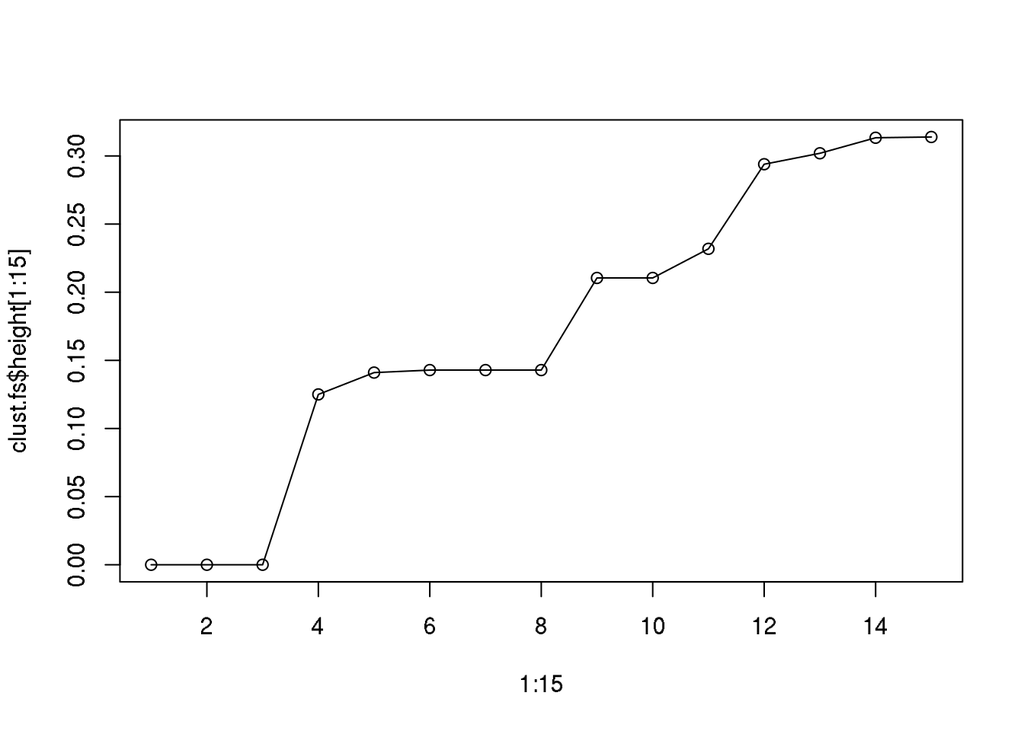

```r
plot(1:15, clust.fs$height[1:15], type = "o")
```

По этому графику перспективными кажутся 3 и 8 кластеров. Значение 3 появлялось и в работе NbClust, посмотрим, как выглядит на дендрограмме разбиение на 3 кластера:

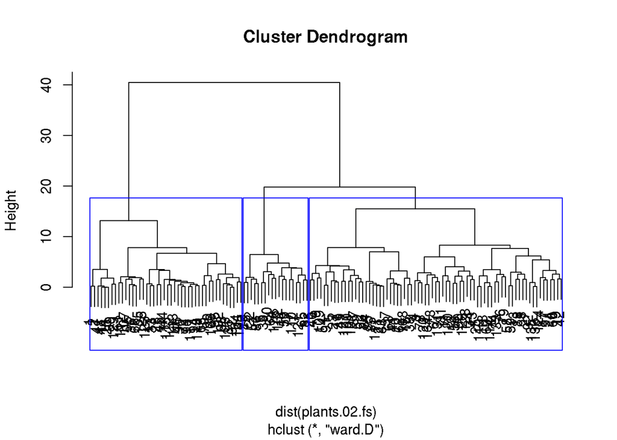

```r
plot(clust.fs)
rect.hclust(clust.fs, k=3, border="blue")
```

В целом, такая кластеризация имеет право на жизнь. Хотя для 136 значений 3 кластера кажутся маленьким количеством, тем более, что кластеры будут очень разные по величине. Количество кластеров 7:

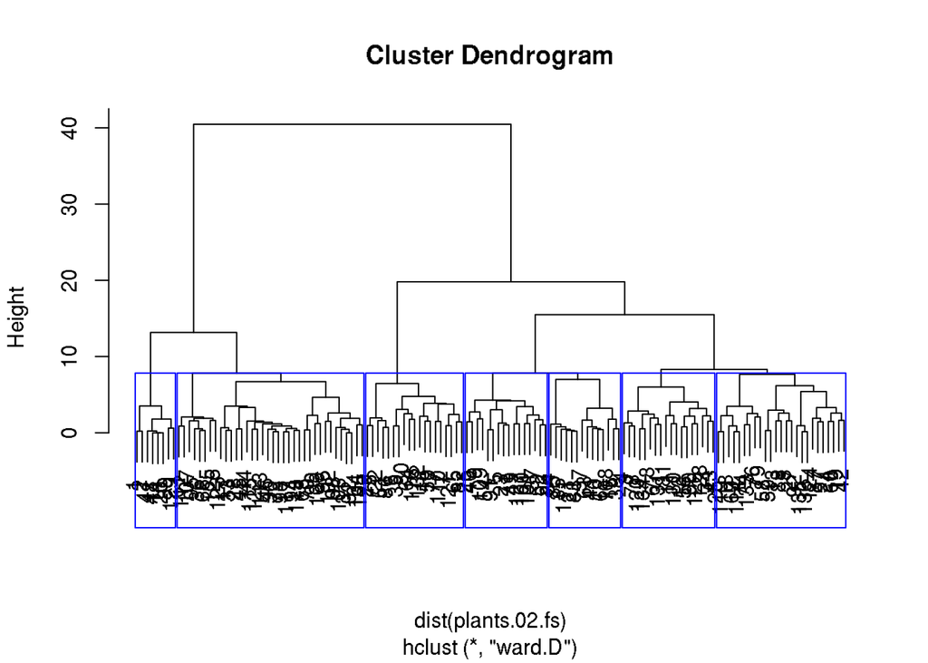

```r
plot(clust.fs)
rect.hclust(clust.fs, k=7, border="blue")
```

На дендрограмме это выглядит не очень естественно, т.к. маленькие расстояния по высоте при переходе к новым объединениям. Остановимся на результате 5 кластеров для такой нормализации, которая выглядит естественнее всего на дендрограмме, а в следующем разделе проинтерпретируем такую кластеризацию.

Дендрограмма для нормализации standard score:

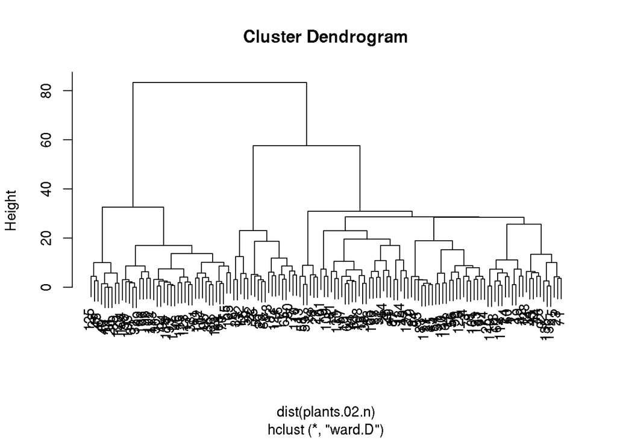

```r
plot(clust.n)
```

Здесь уже сложнее визуально определить количество кластеров. 7 кластеров выглядят неплохо, но если опустить линию чуть ниже, будет 8:

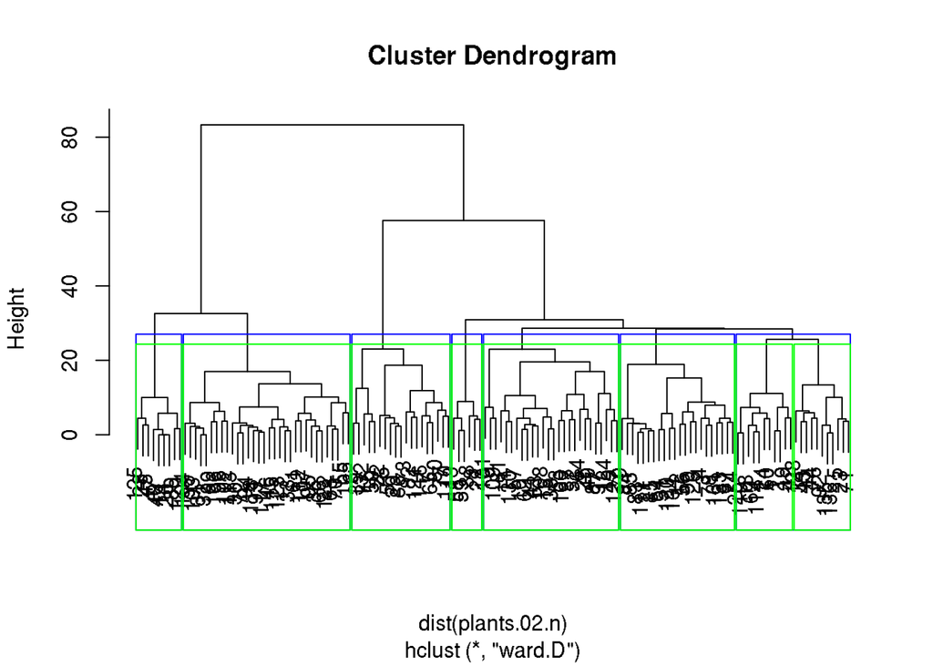

```r
plot(clust.n)
rect.hclust(clust.n, k=7, border="blue")
rect.hclust(clust.n, k=8, border="green")
```

Если проводить линию там, где больше всего разница по высоте, получится 3 кластера – маловато для такой выборки. Посмотрим на результат работы NbClust:

```r
NbClust(data = plants.02.n, method = "ward.D", min.nc = 2, max.nc = 50, index = "kl")
```

```
## $All.index
##      2      3      4      5      6      7      8      9     10     11
## 0.9260 1.9618 1.3773 0.6718 1.2432 0.9301 0.9863 1.4532 0.8180 1.3882
##     12     13     14     15     16     17     18     19     20     21
## 2.0185 0.5126 1.1004 1.6207 0.8627 1.0529 0.7986 1.1540 0.9580 0.9934
##     22     23     24     25     26     27     28     29     30     31
## 1.5722 1.1632 0.7754 1.1878 0.9515 0.8898 1.0543 1.3638 0.7284 1.2522
##     32     33     34     35     36     37     38     39     40     41
## 1.0050 1.3799 0.6778 1.9209 0.5856 1.0968 1.0946 0.8268 1.0488 1.1152
##     42     43     44     45     46     47     48     49     50
## 0.9710 0.9998 1.2030 0.9977 0.9499 1.0879 1.7631 0.6468 0.8798
##
## $Best.nc
## Number_clusters     Value_Index
##         12.0000          2.0185
##
## $Best.partition
##   1   2   3   4   5   6   7   8   9  10  11  12  13  14  15  16  17  18
##   1   1   2   2   3   4   5   6   7   8   2   2   6   9   8   4  10   1
##  19  20  21  22  23  24  25  26  27  28  30  31  32  33  34  35  36  37
##   1   9   8   5   3   1   1  11   6   9  10  10  10  10   3   8  10  11
##  38  40  41  42  43  44  45  46  47  48  49  50  51  52  53  54  55  56
##   8  11   8   1   3   3   9  10   9   9  12   4   5  11  11   3  10   2
##  57  58  59  60  61  64  65  66  67  68  70  71  72  73  74  75  76  78
##   8   6   6   1  10  11   5  10   2  10  10   3  10   5   2   5   3   2
##  79  80  81  82  83  84  85  86  87  88  89  90  91  92  93  95  96  97
##   8   5   2   5   8   8   8   5  12   6   9   2   3   3  10  10  10  12
##  98 100 101 102 104 105 106 107 108 109 110 111 112 113 114 115 116 117
##  10  11   7  10  10  10  10  10   8   7   5   8  10  10   1  10   5  10
## 118 119 120 121 123 124 125 126 127 128 129 130 131 132 133 135 136
##  10   1   2   5  10  12   9   2  12   3   9   2   2   4   2   3   3
```

```r
NbClust(data = plants.02.n, method = "ward.D", min.nc = 2, max.nc = 50, index = "hartigan")
```

```
## $All.index
##       2       3       4       5       6       7       8       9      10
## 15.6855  8.8938  6.6791  8.9666  7.5063  8.1046  8.4334  6.1815  7.5883
##      11      12      13      14      15      16      17      18      19
##  5.7804  3.1920  5.7361  5.3781  3.5415  4.0707  3.9356  4.9295  4.4112
##      20      21      22      23      24      25      26      27      28
##  4.6957  4.8482  3.2431  2.8541  3.6504  3.1573  3.3532  3.8119  3.7011
##      29      30      31      32      33      34      35      36      37
##  2.8090  3.8559  3.1744  3.2133  2.4048  3.5290  1.9345  3.2366  3.0174
##      38      39      40      41      42      43      44      45      46
##  2.8135  3.4475  3.3692  3.0974  3.2569  3.3351  2.8459  2.9073  3.1226
##      47      48      49      50
##  2.9393  1.7265  2.6535  3.0719
##
## $Best.nc
## Number_clusters     Value_Index
##          3.0000          6.7917
##
## $Best.partition
##   1   2   3   4   5   6   7   8   9  10  11  12  13  14  15  16  17  18
##   1   1   1   1   1   2   2   1   1   1   1   1   1   3   1   2   3   1
##  19  20  21  22  23  24  25  26  27  28  30  31  32  33  34  35  36  37
##   1   3   1   2   1   1   1   1   1   3   3   3   3   3   1   1   3   1
##  38  40  41  42  43  44  45  46  47  48  49  50  51  52  53  54  55  56
##   1   1   1   1   1   1   3   3   3   3   1   2   2   1   1   1   3   1
##  57  58  59  60  61  64  65  66  67  68  70  71  72  73  74  75  76  78
##   1   1   1   1   3   1   2   3   1   3   3   1   3   2   1   2   1   1
##  79  80  81  82  83  84  85  86  87  88  89  90  91  92  93  95  96  97
##   1   2   1   2   1   1   1   2   1   1   3   1   1   1   3   3   3   1
##  98 100 101 102 104 105 106 107 108 109 110 111 112 113 114 115 116 117
##   3   1   1   3   3   3   3   3   1   1   2   1   3   3   1   3   2   3
## 118 119 120 121 123 124 125 126 127 128 129 130 131 132 133 135 136
##   3   1   1   2   3   1   3   1   1   1   3   1   1   2   1   1   1
```

```r
NbClust(data = plants.02.n, method = "ward.D", min.nc = 2, max.nc = 50, index = "duda")
```

```
## $All.index
##      2      3      4      5      6      7      8      9     10     11
## 0.8672 0.8990 0.7088 0.8548 0.7323 0.8535 0.6951 0.8377 0.5847 0.7055
##     12     13     14     15     16     17     18     19     20     21
## 0.8424 0.7038 0.6913 0.5849 0.5022 0.7701 0.7424 0.4178 0.5806 0.6722
##     22     23     24     25     26     27     28     29     30     31
## 0.7061 0.8414 0.6857 0.3633 0.5036 0.6155 0.6447 0.6928 1.7859 0.4253
##     32     33     34     35     36     37     38     39     40     41
## 0.6496 0.2066 2.1176 0.5620 1.4248 0.5957 0.5435 2.0249 2.5361 0.4386
##     42     43     44     45     46     47     48     49     50
## 1.7800 1.8789 0.5607 0.4406 5.5914 1.6141 1.0314 0.5471 6.3422
##
## $All.CriticalValues
##      2      3      4      5      6      7      8      9     10     11
## 0.8874 0.8779 0.8387 0.8569 0.8015 0.8487 0.7666 0.8234 0.7108 0.7597
##     12     13     14     15     16     17     18     19     20     21
## 0.8180 0.7340 0.7435 0.7435 0.6793 0.7729 0.7597 0.6004 0.6587 0.6793
##     22     23     24     25     26     27     28     29     30     31
## 0.7108 0.6963 0.7108 0.6004 0.6332 0.6587 0.6332 0.6793 0.5559 0.5559
##     32     33     34     35     36     37     38     39     40     41
## 0.6793 0.6587 0.4907 0.7232 0.5559 0.6332 0.6332 0.4907 0.4907 0.5559
##     42     43     44     45     46     47     48     49     50
## 0.4907 0.6004 0.5559 0.5559 0.3813 0.5559 0.6332 0.6332 0.3813
##
## $Best.nc
## Number_clusters     Value_Index
##           3.000           0.899
##
## $Best.partition
##   1   2   3   4   5   6   7   8   9  10  11  12  13  14  15  16  17  18
##   1   1   1   1   1   2   2   1   1   1   1   1   1   3   1   2   3   1
##  19  20  21  22  23  24  25  26  27  28  30  31  32  33  34  35  36  37
##   1   3   1   2   1   1   1   1   1   3   3   3   3   3   1   1   3   1
##  38  40  41  42  43  44  45  46  47  48  49  50  51  52  53  54  55  56
##   1   1   1   1   1   1   3   3   3   3   1   2   2   1   1   1   3   1
##  57  58  59  60  61  64  65  66  67  68  70  71  72  73  74  75  76  78
##   1   1   1   1   3   1   2   3   1   3   3   1   3   2   1   2   1   1
##  79  80  81  82  83  84  85  86  87  88  89  90  91  92  93  95  96  97
##   1   2   1   2   1   1   1   2   1   1   3   1   1   1   3   3   3   1
##  98 100 101 102 104 105 106 107 108 109 110 111 112 113 114 115 116 117
##   3   1   1   3   3   3   3   3   1   1   2   1   3   3   1   3   2   3
## 118 119 120 121 123 124 125 126 127 128 129 130 131 132 133 135 136
##   3   1   1   2   3   1   3   1   1   1   3   1   1   2   1   1   1
```

```r
NbClust(data = plants.02.n, method = "ward.D", min.nc = 2, max.nc = 50, index = "pseudot2")
```

```
## $All.index
##       2       3       4       5       6       7       8       9      10
## 13.1729  7.8603 14.3779  7.9844  7.6759  7.0348  6.1420  5.4239  5.6824
##      11      12      13      14      15      16      17      18      19
##  5.4263  4.8659  4.2090  4.9129  7.8053  5.9465  4.4790  4.5110  4.1808
##      20      21      22      23      24      25      26      27      28
##  3.6122  2.9259  3.3299  1.3199  3.6671  5.2577  3.9421  3.1239  2.2043
##      29      30      31      32      33      34      35      36      37
##  2.6606 -0.8801  2.7022  3.2366 19.1995 -0.5278  7.0155 -0.5963  2.7152
##      38      39      40      41      42      43      44      45      46
##  3.3604 -0.5062 -0.6057  2.5597 -0.4382 -1.4033  1.5672  2.5393  0.0000
##      47      48      49      50
## -0.7609 -0.1217  3.3111  0.0000
##
## $All.CriticalValues
##       2       3       4       5       6       7       8       9      10
## 10.9097  9.7319  6.7306  7.8509  5.1997  7.3067  4.2631  6.0055  3.2556
##      11      12      13      14      15      16      17      18      19
##  4.1129  5.7850  3.6244  3.7944  3.7944  2.8326  4.4084  4.1129  1.9969
##      20      21      22      23      24      25      26      27      28
##  2.5904  2.8326  3.2556  3.0525  3.2556  1.9969  2.3171  2.5904  2.3171
##      29      30      31      32      33      34      35      36      37
##  2.8326  1.5979  1.5979  2.8326  2.5904  1.0379  3.4454  1.5979  2.3171
##      38      39      40      41      42      43      44      45      46
##  2.3171  1.0379  1.0379  1.5979  1.0379  1.9969  1.5979  1.5979  0.0000
##      47      48      49      50
##  1.5979  2.3171  2.3171  0.0000
##
## $Best.nc
## Number_clusters     Value_Index
##          3.0000          7.8603
##
## $Best.partition
##   1   2   3   4   5   6   7   8   9  10  11  12  13  14  15  16  17  18
##   1   1   1   1   1   2   2   1   1   1   1   1   1   3   1   2   3   1
##  19  20  21  22  23  24  25  26  27  28  30  31  32  33  34  35  36  37
##   1   3   1   2   1   1   1   1   1   3   3   3   3   3   1   1   3   1
##  38  40  41  42  43  44  45  46  47  48  49  50  51  52  53  54  55  56
##   1   1   1   1   1   1   3   3   3   3   1   2   2   1   1   1   3   1
##  57  58  59  60  61  64  65  66  67  68  70  71  72  73  74  75  76  78
##   1   1   1   1   3   1   2   3   1   3   3   1   3   2   1   2   1   1
##  79  80  81  82  83  84  85  86  87  88  89  90  91  92  93  95  96  97
##   1   2   1   2   1   1   1   2   1   1   3   1   1   1   3   3   3   1
##  98 100 101 102 104 105 106 107 108 109 110 111 112 113 114 115 116 117
##   3   1   1   3   3   3   3   3   1   1   2   1   3   3   1   3   2   3
## 118 119 120 121 123 124 125 126 127 128 129 130 131 132 133 135 136
##   3   1   1   2   3   1   3   1   1   1   3   1   1   2   1   1   1
```

```r
NbClust(data = plants.02.n, method = "ward.D", min.nc = 2, max.nc = 50, index = "ratkowsky")
```

```
## $All.index
##      2      3      4      5      6      7      8      9     10     11
## 0.1960 0.2336 0.2404 0.2351 0.2311 0.2267 0.2237 0.2200 0.2158 0.2120
##     12     13     14     15     16     17     18     19     20     21
## 0.2082 0.2031 0.1995 0.1963 0.1925 0.1890 0.1859 0.1836 0.1813 0.1790
##     22     23     24     25     26     27     28     29     30     31
## 0.1768 0.1742 0.1714 0.1694 0.1671 0.1649 0.1630 0.1612 0.1593 0.1576
##     32     33     34     35     36     37     38     39     40     41
## 0.1559 0.1543 0.1526 0.1512 0.1495 0.1481 0.1467 0.1453 0.1441 0.1429
##     42     43     44     45     46     47     48     49     50
## 0.1417 0.1405 0.1394 0.1382 0.1371 0.1361 0.1350 0.1338 0.1328
##
## $Best.nc
## Number_clusters     Value_Index
##          4.0000          0.2404
##
## $Best.partition
##   1   2   3   4   5   6   7   8   9  10  11  12  13  14  15  16  17  18
##   1   1   1   1   1   2   2   1   3   3   1   1   1   4   3   2   4   1
##  19  20  21  22  23  24  25  26  27  28  30  31  32  33  34  35  36  37
##   1   4   3   2   1   1   1   3   1   4   4   4   4   4   1   3   4   3
##  38  40  41  42  43  44  45  46  47  48  49  50  51  52  53  54  55  56
##   3   3   3   1   1   1   4   4   4   4   1   2   2   3   3   1   4   1
##  57  58  59  60  61  64  65  66  67  68  70  71  72  73  74  75  76  78
##   3   1   1   1   4   3   2   4   1   4   4   1   4   2   1   2   1   1
##  79  80  81  82  83  84  85  86  87  88  89  90  91  92  93  95  96  97
##   3   2   1   2   3   3   3   2   1   1   4   1   1   1   4   4   4   1
##  98 100 101 102 104 105 106 107 108 109 110 111 112 113 114 115 116 117
##   4   3   3   4   4   4   4   4   3   3   2   3   4   4   1   4   2   4
## 118 119 120 121 123 124 125 126 127 128 129 130 131 132 133 135 136
##   4   1   1   2   4   1   4   1   1   1   4   1   1   2   1   1   1
```

```r
NbClust(data = plants.02.n, method = "ward.D", min.nc = 2, max.nc = 50, index = "ball")
```

```
## $All.index
##         2         3         4         5         6         7         8
## 1535.3699  907.8115  634.5963  481.1198  373.0576  300.7904  246.2765
##         9        10        11        12        13        14        15
##  204.1941  174.4771  148.7971  129.8151  116.5375  102.9412   91.6384
##        16        17        18        19        20        21        22
##   83.2313   75.5152   68.8123   62.3195   56.8382   51.8145   47.2563
##        23        24        25        26        27        28        29
##   43.8219   40.8528   37.8507   35.2810   32.8613   30.5012   28.3671
##        30        31        32        33        34        35        36
##   26.6420   24.7769   23.2185   21.7630   20.5849   19.2502   18.3216
##        37        38        39        40        41        42        43
##   17.2009   16.1930   15.2836   14.3271   13.4448   12.6579   11.8967
##        44        45        46        47        48        49        50
##   11.1720   10.5529    9.9615    9.3788    8.8500    8.4792    8.0293
##
## $Best.nc
## Number_clusters     Value_Index
##          3.0000        627.5584
##
## $Best.partition
##   1   2   3   4   5   6   7   8   9  10  11  12  13  14  15  16  17  18
##   1   1   1   1   1   2   2   1   1   1   1   1   1   3   1   2   3   1
##  19  20  21  22  23  24  25  26  27  28  30  31  32  33  34  35  36  37
##   1   3   1   2   1   1   1   1   1   3   3   3   3   3   1   1   3   1
##  38  40  41  42  43  44  45  46  47  48  49  50  51  52  53  54  55  56
##   1   1   1   1   1   1   3   3   3   3   1   2   2   1   1   1   3   1
##  57  58  59  60  61  64  65  66  67  68  70  71  72  73  74  75  76  78
##   1   1   1   1   3   1   2   3   1   3   3   1   3   2   1   2   1   1
##  79  80  81  82  83  84  85  86  87  88  89  90  91  92  93  95  96  97
##   1   2   1   2   1   1   1   2   1   1   3   1   1   1   3   3   3   1
##  98 100 101 102 104 105 106 107 108 109 110 111 112 113 114 115 116 117
##   3   1   1   3   3   3   3   3   1   1   2   1   3   3   1   3   2   3
## 118 119 120 121 123 124 125 126 127 128 129 130 131 132 133 135 136
##   3   1   1   2   3   1   3   1   1   1   3   1   1   2   1   1   1
```

```r
NbClust(data = plants.02.n, method = "ward.D", min.nc = 2, max.nc = 50, index = "ptbiserial")
```

```
## $All.index
##      2      3      4      5      6      7      8      9     10     11
## 0.0899 0.3411 0.3915 0.3458 0.3922 0.4068 0.4367 0.4590 0.4681 0.4805
##     12     13     14     15     16     17     18     19     20     21
## 0.4903 0.4124 0.4212 0.4268 0.4112 0.4106 0.3941 0.3934 0.3960 0.4000
##     22     23     24     25     26     27     28     29     30     31
## 0.4056 0.4035 0.3954 0.3932 0.3927 0.3921 0.3932 0.3960 0.3930 0.3948
##     32     33     34     35     36     37     38     39     40     41
## 0.3955 0.3914 0.3854 0.3865 0.3535 0.3545 0.3535 0.3499 0.3508 0.3515
##     42     43     44     45     46     47     48     49     50
## 0.3514 0.3519 0.3530 0.3519 0.3515 0.3519 0.3517 0.3418 0.3371
##
## $Best.nc
## Number_clusters     Value_Index
##         12.0000          0.4903
##
## $Best.partition
##   1   2   3   4   5   6   7   8   9  10  11  12  13  14  15  16  17  18
##   1   1   2   2   3   4   5   6   7   8   2   2   6   9   8   4  10   1
##  19  20  21  22  23  24  25  26  27  28  30  31  32  33  34  35  36  37
##   1   9   8   5   3   1   1  11   6   9  10  10  10  10   3   8  10  11
##  38  40  41  42  43  44  45  46  47  48  49  50  51  52  53  54  55  56
##   8  11   8   1   3   3   9  10   9   9  12   4   5  11  11   3  10   2
##  57  58  59  60  61  64  65  66  67  68  70  71  72  73  74  75  76  78
##   8   6   6   1  10  11   5  10   2  10  10   3  10   5   2   5   3   2
##  79  80  81  82  83  84  85  86  87  88  89  90  91  92  93  95  96  97
##   8   5   2   5   8   8   8   5  12   6   9   2   3   3  10  10  10  12
##  98 100 101 102 104 105 106 107 108 109 110 111 112 113 114 115 116 117
##  10  11   7  10  10  10  10  10   8   7   5   8  10  10   1  10   5  10
## 118 119 120 121 123 124 125 126 127 128 129 130 131 132 133 135 136
##  10   1   2   5  10  12   9   2  12   3   9   2   2   4   2   3   3
```

```r
NbClust(data = plants.02.n, method = "ward.D", min.nc = 2, max.nc = 50, index = "mcclain")
```

```
## $All.index
##       2       3       4       5       6       7       8       9      10
##  0.6930  1.1116  1.9991  2.4011  2.7636  2.9968  3.9660  4.0511  4.9382
##      11      12      13      14      15      16      17      18      19
##  4.9745  5.1725  7.0266  7.2389  7.5746  8.2140  8.4020  9.6080 10.5694
##      20      21      22      23      24      25      26      27      28
## 10.6292 10.7724 10.8783 11.2358 11.8109 12.4154 12.5713 12.8061 13.0682
##      29      30      31      32      33      34      35      36      37
## 13.1735 13.5827 13.5922 13.6691 14.2482 14.8384 14.8434 17.5491 17.6103
##      38      39      40      41      42      43      44      45      46
## 17.9781 18.5688 18.5858 18.6111 18.7687 18.8064 18.8652 19.0816 19.2432
##      47      48      49      50
## 19.2406 19.3486 20.4979 21.2158
##
## $Best.nc
## Number_clusters     Value_Index
##           2.000           0.693
##
## $Best.partition
##   1   2   3   4   5   6   7   8   9  10  11  12  13  14  15  16  17  18
##   1   1   1   1   1   1   1   1   1   1   1   1   1   2   1   1   2   1
##  19  20  21  22  23  24  25  26  27  28  30  31  32  33  34  35  36  37
##   1   2   1   1   1   1   1   1   1   2   2   2   2   2   1   1   2   1
##  38  40  41  42  43  44  45  46  47  48  49  50  51  52  53  54  55  56
##   1   1   1   1   1   1   2   2   2   2   1   1   1   1   1   1   2   1
##  57  58  59  60  61  64  65  66  67  68  70  71  72  73  74  75  76  78
##   1   1   1   1   2   1   1   2   1   2   2   1   2   1   1   1   1   1
##  79  80  81  82  83  84  85  86  87  88  89  90  91  92  93  95  96  97
##   1   1   1   1   1   1   1   1   1   1   2   1   1   1   2   2   2   1
##  98 100 101 102 104 105 106 107 108 109 110 111 112 113 114 115 116 117
##   2   1   1   2   2   2   2   2   1   1   1   1   2   2   1   2   1   2
## 118 119 120 121 123 124 125 126 127 128 129 130 131 132 133 135 136
##   2   1   1   1   2   1   2   1   1   1   2   1   1   1   1   1   1
```

Большинство методов предлагают 3 кластера. График каменистой насыпи:

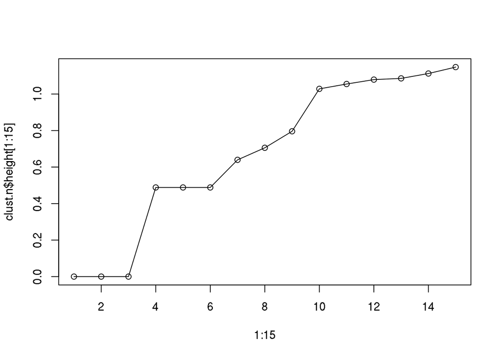

```r
plot(1:15, clust.n$height[1:15], type = "o")
```

И здесь 3 выглядит неплохо. Оставим для такой нормализации несколько вариантов количества кластеров: 3, 7, 8, и перейдём к интерпретации результата:

#### Интерпретация результатов

Рассмотрим и для первой нормализации 3 кластера:

```r
groups.fs.3 <- cutree(clust.fs, k=3)
groups.fs.3
```

```
##   [1] 1 1 2 2 2 3 3 2 2 2 2 2 2 1 2 3 1 2 2 1 2 3 2 2 2 2 2 1 3 1 1 1 1 2 2
##  [36] 1 2 2 3 2 2 2 2 1 1 1 1 1 2 3 3 2 2 2 1 2 2 2 2 2 1 2 2 3 3 1 2 1 2 1
##  [71] 2 1 2 2 3 2 3 2 2 3 2 3 2 2 2 3 2 2 1 2 2 2 1 1 1 1 2 1 1 2 2 1 1 1 1
## [106] 1 1 2 2 3 2 1 1 2 1 3 1 1 2 2 3 1 1 2 1 2 2 2 1 2 2 3 2 2 2 2
```

```r
#  в 1-м кластере
colMeans(na.omit(plants.02[groups.fs.3==1,  2:29]))*100
```

```
##   durflow    height   begflow    vegaer   vegsout  autopoll   insects
##     260.0     647.5     462.5      12.5      35.0      42.5     250.0
##      wind      lign       piq       ros   semiros     leafy     suman
##      85.0      90.0      25.0       0.0       0.0     100.0       0.0
##     winan  monocarp  polycarp   seasaes   seashiv   seasver   everalw
##       0.0       0.0     100.0      72.5       0.0       0.0      20.0
## everparti     elaio   endozoo    epizoo     aquat    windgl      unsp
##       7.5       2.5      77.5       0.0       0.0      20.0       2.5
```

```r
#  во 2-ом кластере
colMeans(na.omit(plants.02[groups.fs.3==2, 2:29]))*100
```

```
##    durflow     height    begflow     vegaer    vegsout   autopoll
## 320.289855 291.304348 542.028986  31.884058  55.072464  78.260870
##    insects       wind       lign        piq        ros    semiros
## 189.855072 114.492754   4.347826   5.797101  17.391304  37.681159
##      leafy      suman      winan   monocarp   polycarp    seasaes
##  44.927536   1.449275   1.449275   8.695652  97.101449  14.492754
##    seashiv    seasver    everalw  everparti      elaio    endozoo
##   0.000000   8.695652  60.869565  14.492754  14.492754   4.347826
##     epizoo      aquat     windgl       unsp
##  26.086957   4.347826  17.391304  39.130435
```

```r
#  в 3-ем кластере
colMeans(na.omit(plants.02[groups.fs.3==3,  2:29]))*100
```

```
##   durflow    height   begflow    vegaer   vegsout  autopoll   insects
##    462.50    343.75    543.75      0.00      6.25    237.50    156.25
##      wind      lign       piq       ros   semiros     leafy     suman
##     50.00      0.00      6.25      0.00     50.00     50.00     93.75
##     winan  monocarp  polycarp   seasaes   seashiv   seasver   everalw
##     62.50     12.50     12.50     31.25     25.00      0.00      6.25
## everparti     elaio   endozoo    epizoo     aquat    windgl      unsp
##     37.50      6.25      0.00     12.50      0.00     18.75     62.50
```

В первом кластере заметно больше следующие значения: height, lign, leafy, seasaes, endozoo. Второй кластер отличается от двух других тем, что у него высокие показатели следующих значений (в двух других они могут быть равны 0): ros, seasver, everalw, elaio, epizoo. В третьем кластере выделяются такие значения: autopoll, semiros, suman, winam, seashiv, everparti, unsp. Обращаясь к расшифровке значений, можно так охарактеризовать кластеры: в первый кластер попали самые высокие растения, которые являются лиственными деревьями (lign и leafy). Кроме того, плоды спрятаны. Кратко – это деревья. Второй кластер характеризуется тем, что здесь есть розоцветные, плоды внутренние, вечнозелёные. В третьем кластере самоопыляемые, часто полурозоцветные, с летним периодом цветения, часто и зимний период цветения, частично вечнозелёные, неспецифичный механизм распространения семян.

Этот же набор данных и 5 кластеров:

```r
groups.fs.5 <- cutree(clust.fs, k=5)
groups.fs.5
```

```
##   [1] 1 1 2 2 3 4 4 2 3 3 2 2 2 1 3 4 5 2 2 1 3 4 3 2 2 3 2 5 4 5 5 5 5 2 3
##  [36] 5 3 3 4 3 3 2 2 5 5 5 1 1 3 4 4 3 3 3 5 2 3 2 2 2 5 3 3 4 4 5 2 5 2 5
##  [71] 3 5 2 2 4 2 4 2 2 4 2 4 3 3 3 4 2 2 1 2 3 2 5 5 5 5 2 5 5 3 3 5 5 5 5
## [106] 5 5 3 3 4 3 5 5 2 5 4 5 5 2 2 4 5 5 2 5 2 3 2 1 2 2 4 2 2 2 2
```

```r
#  в 1-м кластере
colMeans(na.omit(plants.02[groups.fs.5==1, 2:29]))*100
```

```
##   durflow    height   begflow    vegaer   vegsout  autopoll   insects
##     200.0     787.5     375.0       0.0      37.5       0.0     112.5
##      wind      lign       piq       ros   semiros     leafy     suman
##     287.5     100.0       0.0       0.0       0.0     100.0       0.0
##     winan  monocarp  polycarp   seasaes   seashiv   seasver   everalw
##       0.0       0.0     100.0     100.0       0.0       0.0       0.0
## everparti     elaio   endozoo    epizoo     aquat    windgl      unsp
##       0.0       0.0       0.0       0.0       0.0     100.0       0.0
```

```r
#  во 2-м кластере
colMeans(na.omit(plants.02[groups.fs.5==2, 2:29]))*100
```

```
##    durflow     height    begflow     vegaer    vegsout   autopoll
## 319.512195 309.756098 556.097561  19.512195  80.487805  80.487805
##    insects       wind       lign        piq        ros    semiros
## 217.073171  82.926829   7.317073   7.317073  24.390244   7.317073
##      leafy      suman      winan   monocarp   polycarp    seasaes
##  68.292683   2.439024   2.439024   0.000000 100.000000  21.951220
##    seashiv    seasver    everalw  everparti      elaio    endozoo
##   0.000000  14.634146  36.585366  24.390244  17.073171   4.878049
##     epizoo      aquat     windgl       unsp
##  14.634146   0.000000  21.951220  46.341463
```

```r
#  в 3-м кластере
colMeans(na.omit(plants.02[groups.fs.5==3,  2:29]))*100
```

```
##    durflow     height    begflow     vegaer    vegsout   autopoll
## 321.428571 264.285714 521.428571  50.000000  17.857143  75.000000
##    insects       wind       lign        piq        ros    semiros
## 150.000000 160.714286   0.000000   3.571429   7.142857  82.142857
##      leafy      suman      winan   monocarp   polycarp    seasaes
##  10.714286   0.000000   0.000000  21.428571  92.857143   3.571429
##    seashiv    seasver    everalw  everparti      elaio    endozoo
##   0.000000   0.000000  96.428571   0.000000  10.714286   3.571429
##     epizoo      aquat     windgl       unsp
##  42.857143  10.714286  10.714286  28.571429
```

```r
#  в 4-м кластере
colMeans(na.omit(plants.02[groups.fs.5==4, 2:29]))*100
```

```
##   durflow    height   begflow    vegaer   vegsout  autopoll   insects
##    462.50    343.75    543.75      0.00      6.25    237.50    156.25
##      wind      lign       piq       ros   semiros     leafy     suman
##     50.00      0.00      6.25      0.00     50.00     50.00     93.75
##     winan  monocarp  polycarp   seasaes   seashiv   seasver   everalw
##     62.50     12.50     12.50     31.25     25.00      0.00      6.25
## everparti     elaio   endozoo    epizoo     aquat    windgl      unsp
##     37.50      6.25      0.00     12.50      0.00     18.75     62.50
```

```r
#  в 5-м кластере
colMeans(na.omit(plants.02[groups.fs.5==5,  2:29]))*100
```

```
##   durflow    height   begflow    vegaer   vegsout  autopoll   insects
##   275.000   612.500   484.375    15.625    34.375    53.125   284.375
##      wind      lign       piq       ros   semiros     leafy     suman
##    34.375    87.500    31.250     0.000     0.000   100.000     0.000
##     winan  monocarp  polycarp   seasaes   seashiv   seasver   everalw
##     0.000     0.000   100.000    65.625     0.000     0.000    25.000
## everparti     elaio   endozoo    epizoo     aquat    windgl      unsp
##     9.375     3.125    96.875     0.000     0.000     0.000     3.125
```

В первом кластере самые высокие растения, все растения лиственные деревья, плоды которых разносятся ветром. Во втором больше всего vegsout – подземное вегетативное размножение, распространение плодов насекомыми. растения лиственные, но не деревья. В третьем кластере больше всего полурозоцветных и вечнозелёных, многократно плодоносящих. В четвёртом кластере мало многократно плодоносящих растений (polycarp) и много самоопыляющихся, с цветением летом и зимой. В пятом кластере немало растений с шипами (piq), при этом они достаточно высокие и все многократно плодоносят, плоды почти всегда внутренние и опыление происходит с помощью насекомых.

Посмотрим на 7 кластеров для второй нормализации (разбиение на 3 вряд ли будет отличаться от первой нормализации):

```r
groups.n.7 <- cutree(clust.n, k=7)
groups.n.7
```

```
##   1   2   3   4   5   6   7   8   9  10  11  12  13  14  15  16  17  18
##   1   1   2   2   1   3   3   4   5   5   5   2   4   6   5   3   7   1
##  19  20  21  22  23  24  25  26  27  28  29  30  31  32  33  34  35  36
##   1   6   2   3   1   1   1   5   4   6   3   7   7   7   7   1   2   7
##  37  38  39  40  41  42  43  44  45  46  47  48  49  50  51  52  53  54
##   5   5   3   5   5   1   1   1   6   7   6   6   5   3   3   5   5   2
##  55  56  57  58  59  60  61  62  63  64  65  66  67  68  69  70  71  72
##   7   2   5   4   4   1   7   5   5   5   3   7   2   7   1   7   1   7
##  73  74  75  76  77  78  79  80  81  82  83  84  85  86  87  88  89  90
##   3   2   3   1   3   2   2   3   5   3   2   2   2   3   5   4   6   2
##  91  92  93  94  95  96  97  98  99 100 101 102 103 104 105 106 107 108
##   2   1   7   7   7   7   5   7   7   5   5   7   7   7   7   7   7   5
## 109 110 111 112 113 114 115 116 117 118 119 120 121 122 123 124 125 126
##   5   3   2   7   7   1   7   3   7   7   1   2   3   7   7   5   6   2
## 127 128 129 130 131 132 133 134 135 136
##   5   1   6   5   2   3   2   2   1   1
```

```r
options(digits=4)
#  в 1-м кластере
colMeans(na.omit(plants.02[groups.n.7==1, 2:29]))*100
```

```
##   durflow    height   begflow    vegaer   vegsout  autopoll   insects
##   290.476   371.429   523.810    14.286    61.905    61.905   290.476
##      wind      lign       piq       ros   semiros     leafy     suman
##    33.333    28.571     9.524    14.286    14.286    71.429     0.000
##     winan  monocarp  polycarp   seasaes   seashiv   seasver   everalw
##     0.000     0.000   100.000    38.095     0.000     0.000    42.857
## everparti     elaio   endozoo    epizoo     aquat    windgl      unsp
##    14.286    52.381     4.762     9.524     0.000    38.095     9.524
```

```r
#  во 2-ом кластере
colMeans(na.omit(plants.02[groups.n.7==2, 2:29]))*100
```

```
##   durflow    height   begflow    vegaer   vegsout  autopoll   insects
##    295.24    285.71    542.86     57.14     38.10     80.95    128.57
##      wind      lign       piq       ros   semiros     leafy     suman
##    190.48      0.00      0.00      0.00     42.86     57.14      0.00
##     winan  monocarp  polycarp   seasaes   seashiv   seasver   everalw
##      0.00      0.00    100.00     14.29      0.00      0.00     66.67
## everparti     elaio   endozoo    epizoo     aquat    windgl      unsp
##     19.05      0.00      0.00      0.00      0.00      0.00    100.00
```

```r
#  в 3-м кластере
colMeans(na.omit(plants.02[groups.n.7==3, 2:29]))*100
```

```
##   durflow    height   begflow    vegaer   vegsout  autopoll   insects
##    481.25    331.25    531.25      0.00      6.25    237.50    162.50
##      wind      lign       piq       ros   semiros     leafy     suman
##     50.00      0.00      0.00      0.00     43.75     56.25     93.75
##     winan  monocarp  polycarp   seasaes   seashiv   seasver   everalw
##     68.75      6.25     18.75     31.25     25.00      0.00     12.50
## everparti     elaio   endozoo    epizoo     aquat    windgl      unsp
##     31.25      6.25      0.00     12.50      0.00     12.50     68.75
```

```r
#  в 4-м кластере
colMeans(na.omit(plants.02[groups.n.7==4, 2:29]))*100
```

```
##   durflow    height   begflow    vegaer   vegsout  autopoll   insects
##    216.67    216.67    433.33      0.00    100.00     33.33    333.33
##      wind      lign       piq       ros   semiros     leafy     suman
##      0.00      0.00      0.00     50.00     33.33     16.67      0.00
##     winan  monocarp  polycarp   seasaes   seashiv   seasver   everalw
##      0.00      0.00    100.00      0.00      0.00    100.00      0.00
## everparti     elaio   endozoo    epizoo     aquat    windgl      unsp
##      0.00      0.00     33.33     16.67      0.00      0.00     50.00
```

```r
#  в 5-м кластере
colMeans(na.omit(plants.02[groups.n.7==5, 2:29]))*100
```

```
##   durflow    height   begflow    vegaer   vegsout  autopoll   insects
##   370.833   304.167   583.333    29.167    45.833    91.667   137.500
##      wind      lign       piq       ros   semiros     leafy     suman
##   133.333     0.000    12.500    25.000    54.167    20.833     4.167
##     winan  monocarp  polycarp   seasaes   seashiv   seasver   everalw
##     0.000    29.167    87.500     8.333     0.000     0.000    75.000
## everparti     elaio   endozoo    epizoo     aquat    windgl      unsp
##    16.667     0.000     4.167    62.500    12.500    29.167     0.000
```

```r
#  в 6-м кластере
colMeans(na.omit(plants.02[groups.n.7==6, 2:29]))*100
```

```
##   durflow    height   begflow    vegaer   vegsout  autopoll   insects
##    211.11    777.78    322.22     11.11     44.44      0.00     11.11
##      wind      lign       piq       ros   semiros     leafy     suman
##    377.78    100.00      0.00      0.00      0.00    100.00      0.00
##     winan  monocarp  polycarp   seasaes   seashiv   seasver   everalw
##      0.00      0.00    100.00     88.89      0.00      0.00     11.11
## everparti     elaio   endozoo    epizoo     aquat    windgl      unsp
##      0.00      0.00     33.33      0.00      0.00     66.67      0.00
```

```r
#  в 7-м кластере
colMeans(na.omit(plants.02[groups.n.7==7, 2:29]))*100
```

```
##   durflow    height   begflow    vegaer   vegsout  autopoll   insects
##   278.571   600.000   507.143    14.286    35.714    60.714   314.286
##      wind      lign       piq       ros   semiros     leafy     suman
##     0.000    85.714    35.714     0.000     0.000   100.000     0.000
##     winan  monocarp  polycarp   seasaes   seashiv   seasver   everalw
##     0.000     0.000   100.000    64.286     0.000     0.000    25.000
## everparti     elaio   endozoo    epizoo     aquat    windgl      unsp
##    10.714     0.000    96.429     0.000     0.000     0.000     3.571
```

В целом разбиение на 3 или 5 кластеров логичнее разбивает данные, чем 7 кластеров.

#### Бонус

Этот набор данных является встроенным в пакет cluster, и авторы предлагают количество кластеров, равное 6 (код со страницы https://stat.ethz.ch/R-manual/R-devel/library/cluster/html/plantTraits.html ):

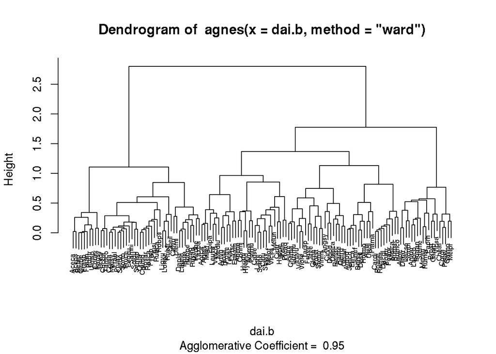

```r
library(cluster)
data(plantTraits)

## Calculation of a dissimilarity matrix

dai.b <- daisy(plantTraits, type = list(ordratio = 4:11, symm = 12:13, asymm = 14:31))

## Hierarchical classification
agn.trts <- agnes(dai.b, method="ward")
plot(agn.trts, which.plots = 2, cex= 0.6)
```

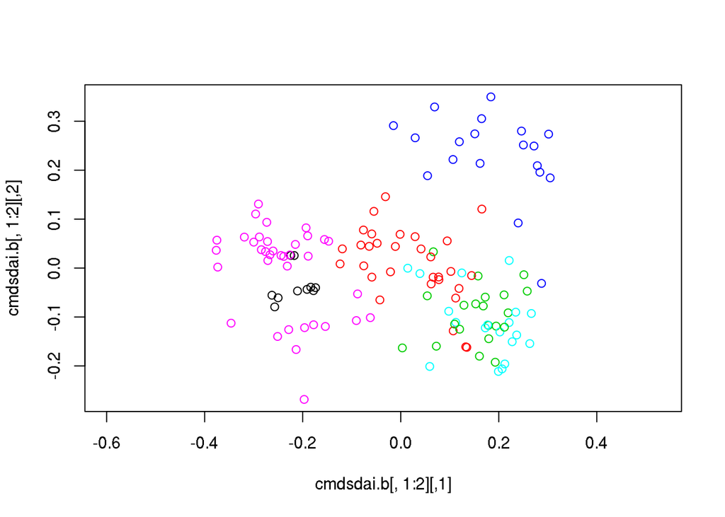

```r
cutree6 <- cutree(agn.trts, k=6)

## Principal Coordinate Analysis
cmdsdai.b <- cmdscale(dai.b, k=6)
plot(cmdsdai.b[, 1:2], asp = 1, col = cutree6)
```